# Data Chek ver3 last biz day version

This is to use IvyDB pricedata and another factor DB to tou ji dao ba. This file is to check the basic data integrity. It is reading from the root directory for the simplicity now.

Now I am buring the previous data prep step so we will have fewer ouputs we will just check the graphs for each factor

### *Step.1 Read IVYDB mapping and ZY DB to inner_join on cusip.*

### *Step.2 Check All the factors*

1. Get the all factor file。

```r
# get all the factors
factors<-fread("ss.csv")

colnames(factors)=c("Date","CUSIP","Factor","Value")
factors<-factors %>%
  mutate(Date=as.Date(Date),Y=year(Date),M=month(Date)) %>%
  mutate(CUSIP=str_sub(CUSIP,start=1,end=-2)) # CUSIP treatment

print(head(factors))
```

```
##          Date    CUSIP Factor     Value    Y M
## 1: 2007-05-31 00088630     bp 0.2781827 2007 5
## 2: 2007-05-31 00105510     bp 0.3283182 2007 5
## 3: 2007-05-31 00130H10     bp 0.1350981 2007 5
## 4: 2007-05-31 00163T10     bp 0.6084470 2007 5
## 5: 2007-05-31 00206R10     bp 0.4432026 2007 5
## 6: 2007-05-31 00282410     bp 0.1509988 2007 5
```

2. Get the IVYDB price data and inner_join with the mapping info at first. Check old rmd file for explanations.

```r
# using feather data now. Can switch to fst for faster data load if working with R only
pricedata<-rio::import("JQCpricedata.feather")
print(head(pricedata))
```

```
##         Date SecurityID Price        Volume TotalReturn splitAdj
## 1 1996-01-02       5001 7.625 9.337841e-320    0.000000        1
## 2 1996-01-03       5001 8.500 2.519735e-320    0.114754        1
## 3 1996-01-04       5001 8.500 4.940656e-322    0.000000        1
## 4 1996-01-05       5001 8.000 7.312172e-320   -0.058824        1
## 5 1996-01-08       5001 8.000 9.881313e-322    0.000000        1
## 6 1996-01-09       5001 7.250 2.282583e-319   -0.093750        1
##   SharesOutstanding Adj     cap Adj_prices    Cumret Adj_prices2     ratio
## 1              5052   1 38521.5      7.625 1.0000000    7.625000 1.0000000
## 2              5052   1 42942.0      8.500 1.1147540    8.499999 0.9999999
## 3              5052   1 42942.0      8.500 1.1147540    8.499999 0.9999999
## 4              5052   1 40416.0      8.000 1.0491797    7.999995 0.9999994
## 5              5052   1 40416.0      8.000 1.0491797    7.999995 0.9999994
## 6              5052   1 36627.0      7.250 0.9508191    7.249996 0.9999994
##   tempSPX size_rank
## 1  620.73      2820
## 2  621.32      2770
## 3  617.70      2785
## 4  616.71      2861
## 5  618.46      2874
## 6  609.45      2945
```

```r
newpricedata<-pricedata %>%
  inner_join(finalmapping,by="SecurityID") # about 1/10 of the all stock data, make sense ha
print(head(newpricedata))
```

```
##         Date SecurityID  Price        Volume TotalReturn splitAdj
## 1 1996-01-02     100892 44.375 7.238062e-319    0.000000        1
## 2 1996-01-03     100892 45.875 1.080522e-318    0.033803        1
## 3 1996-01-04     100892 45.375 8.354650e-319   -0.010899        1
## 4 1996-01-05     100892 45.250 8.735081e-319   -0.002755        1
## 5 1996-01-08     100892 45.500 7.855644e-320    0.005525        1
## 6 1996-01-09     100892 45.250 5.681755e-319   -0.005495        1
##   SharesOutstanding Adj     cap Adj_prices   Cumret Adj_prices2    ratio
## 1             94753   1 4204664   2.354632 1.000000    44.37500 18.84583
## 2             94753   1 4346794   2.434225 1.033803    45.87501 18.84583
## 3             94753   1 4299417   2.407694 1.022536    45.37502 18.84584
## 4             94753   1 4287573   2.401062 1.019718    45.25001 18.84583
## 5             94753   1 4311262   2.414327 1.025352    45.50001 18.84584
## 6             94753   1 4287573   2.401062 1.019718    45.24999 18.84583
##   tempSPX size_rank    CUSIP Ticker    BBG  Name
## 1  620.73       223 00105510 AFL    AFL UN AFLAC
## 2  621.32       215 00105510 AFL    AFL UN AFLAC
## 3  617.70       216 00105510 AFL    AFL UN AFLAC
## 4  616.71       218 00105510 AFL    AFL UN AFLAC
## 5  618.46       215 00105510 AFL    AFL UN AFLAC
## 6  609.45       216 00105510 AFL    AFL UN AFLAC
```

3. Combine with each factor info. 看起来所有因子都对齐到了月末 所以可以用一个简单的办法change the factor df to wide format with each col being a single factor (这个要取决与数据格式 以后不一定这样合适哈) <1> Inner_join style on Date.

```r
# expand factors to wide format
factors_w<-factors %>%
  pivot_wider(names_from = Factor,values_from = Value) # default is fill NA for missing factors

## 现在看会有很多NA 所以后面算ML或者因子收益要多注意了， 这么多NA对ML有很多挑战 我之前也没有搞过这么多NA的，要我们一起
#看这些NA的来的原因和是否可以fillna from prev non-na
print(factors_w)
```

```
## # A tibble: 105,327 x 25
##    Date       CUSIP     Y     M     bp   g_e6 cfototcap neg_d_recsale
##    <date>     <chr> <int> <int>  <dbl>  <dbl>     <dbl>         <dbl>
##  1 2007-05-31 0008~  2007     5 0.278   0.666   0.0736        0.0455
##  2 2007-05-31 0010~  2007     5 0.328   1.14    0.0612       -0.00591
##  3 2007-05-31 0013~  2007     5 0.135   0.861   0.113        -0.0155
##  4 2007-05-31 0016~  2007     5 0.608   1.09    0.0634        0.0247
##  5 2007-05-31 0020~  2007     5 0.443   1.02    0.0601       -0.0294
##  6 2007-05-31 0028~  2007     5 0.151   0.969   0.0563        0.00960
##  7 2007-05-31 0028~  2007     5 0.133   1.18    0.0834        0.00200
##  8 2007-05-31 0049~  2007     5 0.0919 NA       0.00810       0.0198
##  9 2007-05-31 0072~  2007     5 0.121   1.11    0.0426        0.0111
## 10 2007-05-31 0075~  2007     5 0.232  NA       0.0689        0.00118
## # ... with 105,317 more rows, and 17 more variables: neg_g_employee1 <dbl>,
## #   neg_coaaccru <dbl>, d_cfmargin <dbl>, neg_g_employee2 <dbl>,
## #   neg_g_employee3 <dbl>, neg_noa <dbl>, g_e4 <dbl>, neg_g_sale3 <dbl>,
## #   neg_d_invsale <dbl>, d_grossmargin <dbl>, g_e5 <dbl>, neg_g_sale5 <dbl>,
## #   neg_ncoaaccru <dbl>, d_nimargin <dbl>, d_soa <dbl>, fcfototcap <dbl>,
## #   finaccru <dbl>
```

Now we can combine the factors with the price data

```r
final<-newpricedata %>%
  select(Date,SecurityID,CUSIP,BBG,size_rank,Price,Cumret,tempSPX) %>%
  inner_join(factors_w,by=c("CUSIP","Date"))
```

4. Use the factors to evaluate the factor performance.In my codes “y” is the return for the next period. We will use decile rank for now and we can use Z-score weighted neutral style.

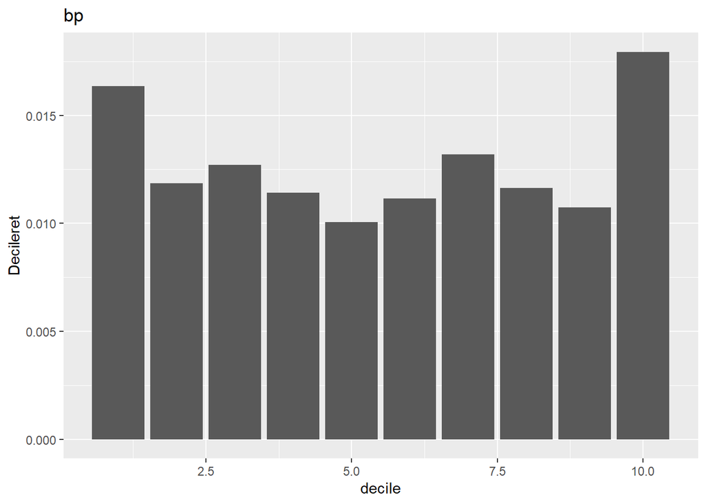

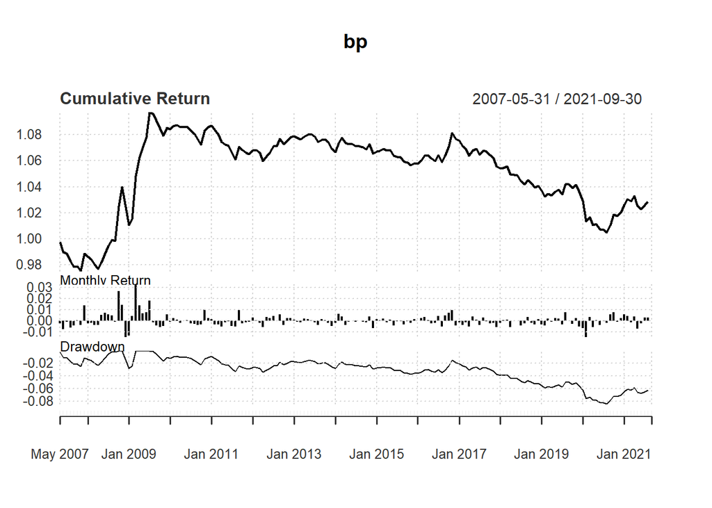

```
##                                     bp
## Annualized Return           0.00200000
## Annualized Std Dev          0.01990000
## Annualized Sharpe (Rf=0%)   0.09930000
## Max DD                      0.08424519
## Calmar Ratio                0.02349625
## # of trades               172.00000000
```

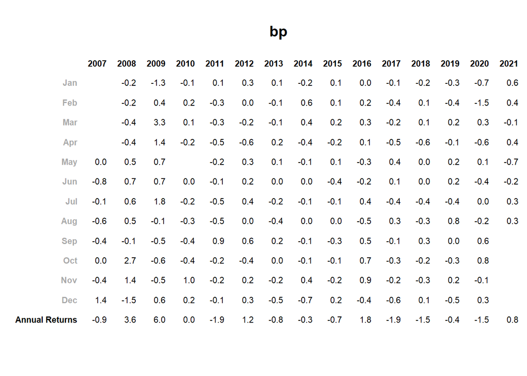

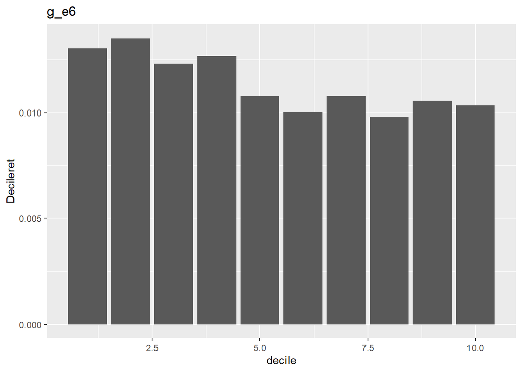

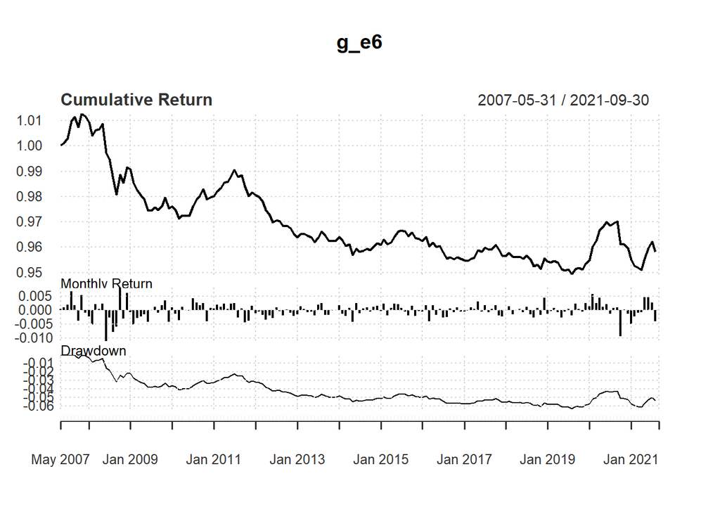

```
##                                   g_e6
## Annualized Return          -0.00300000
## Annualized Std Dev          0.00940000
## Annualized Sharpe (Rf=0%)  -0.31910000
## Max DD                      0.06277542
## Calmar Ratio               -0.04758000
## # of trades               172.00000000
```

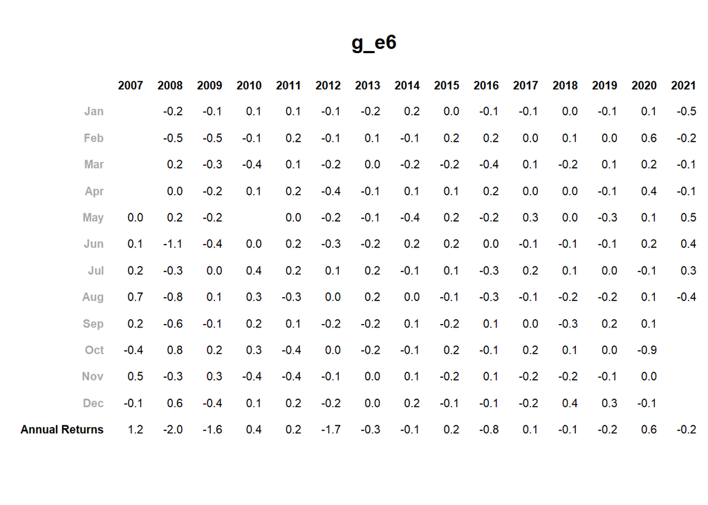

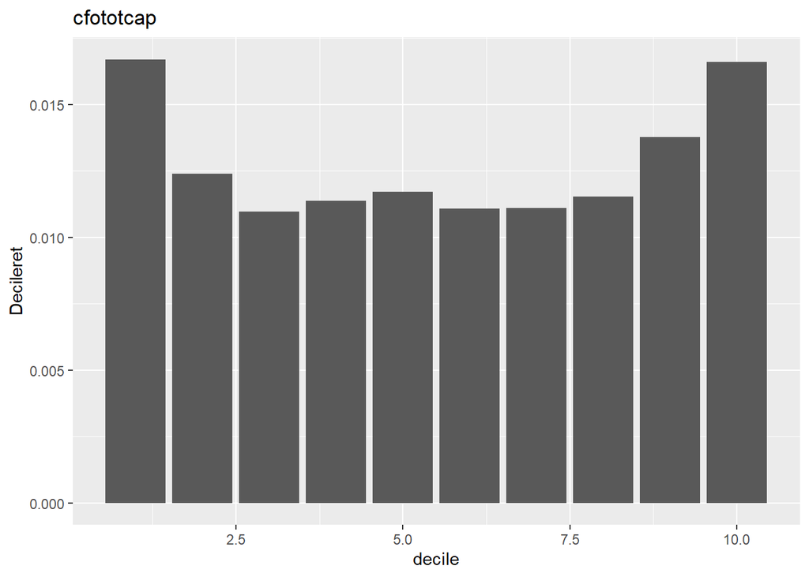

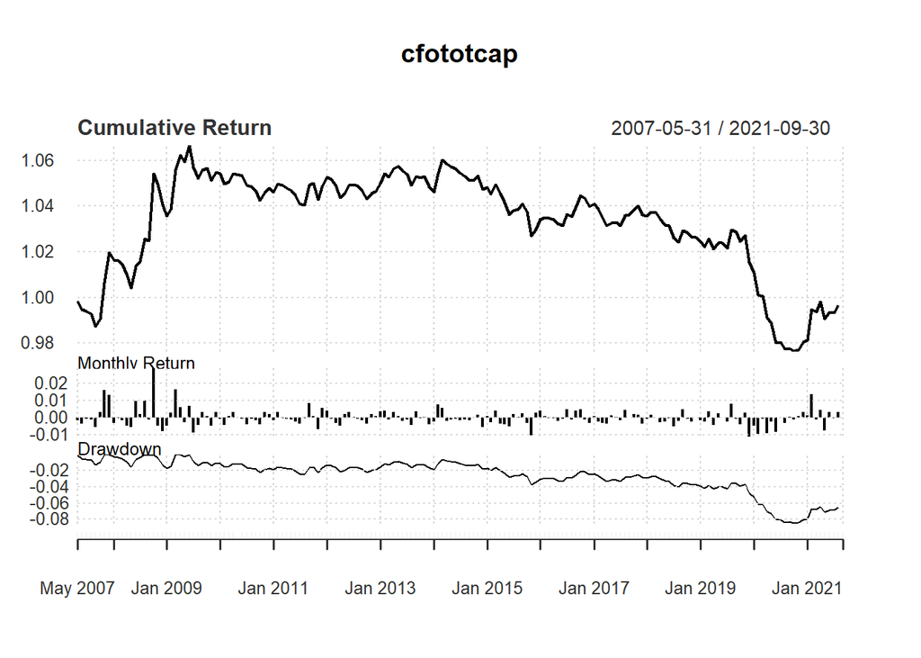

```
##                               cfototcap
## Annualized Return          -0.000200000
## Annualized Std Dev          0.017100000
## Annualized Sharpe (Rf=0%)  -0.014400000
## Max DD                      0.084462485
## Calmar Ratio               -0.002909475
## # of trades               172.000000000
```

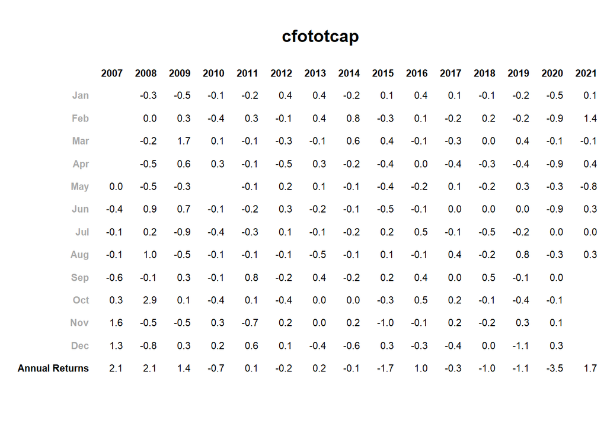

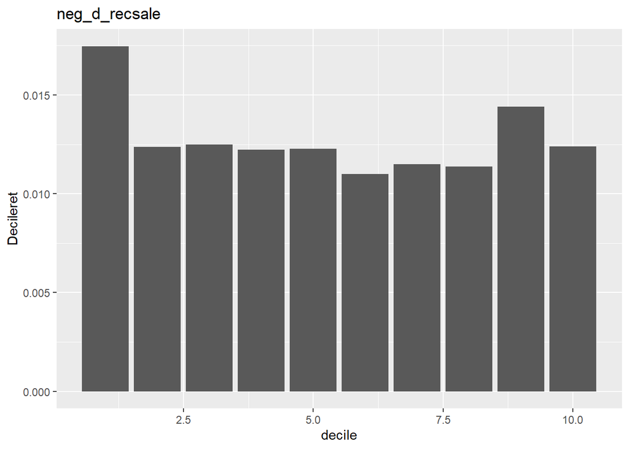

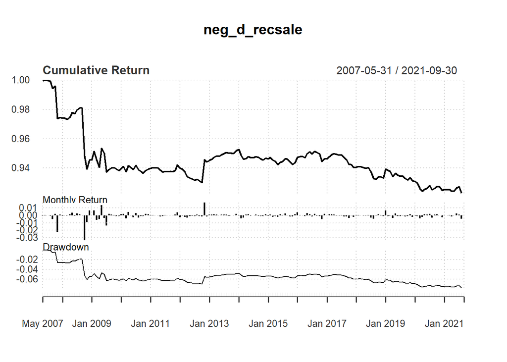

```
##                           neg_d_recsale
## Annualized Return           -0.00560000
## Annualized Std Dev           0.01470000
## Annualized Sharpe (Rf=0%)   -0.38330000
## Max DD                       0.07737140
## Calmar Ratio                -0.07270667
## # of trades                172.00000000
```

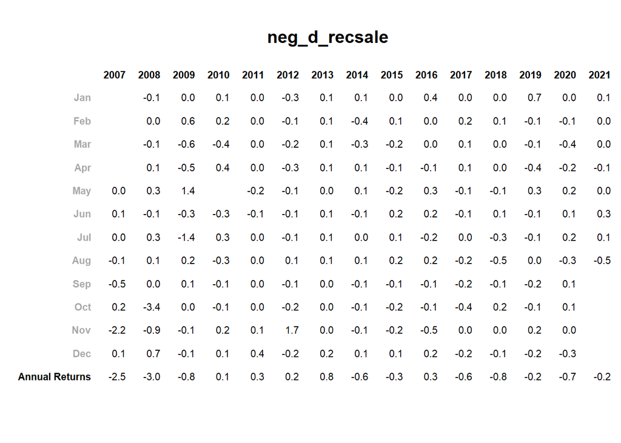

[51 more figures not shown]

```
##                               finaccru
## Annualized Return           0.00090000
## Annualized Std Dev          0.01080000
## Annualized Sharpe (Rf=0%)   0.08710000
## Max DD                      0.02876122
## Calmar Ratio                0.03267342
## # of trades               172.00000000
```

```r
factordata<-final %>%
  group_by(SecurityID) %>%
  arrange(Date) %>%
  mutate(y=lead(Cumret)/Cumret)  # you cannot do na.omit at this stage as you have so many NAs for factor columns

divs=10 # deciles.

factornames=colnames(factordata)[11:(ncol(factordata)-1)]
nfactors=length(factornames)

for (i in 1:nfactors)
{
  var=factornames[i]
  factorret<-factordata %>%
  group_by(M,Y) %>%
  mutate(decile=ntile(get(var),divs)) %>%
  group_by(M,Y,decile) %>%
  summarise(decileret=mean(y,na.rm=T)-1,Date=min(Date))

p1<-factorret %>%
    group_by(decile) %>%
    summarise(Decileret=mean(decileret,na.rm=T)) %>%
    ggplot(aes(x=decile,y=Decileret)) + geom_bar(stat = "identity") + ggtitle(var)
print(p1)

LSret<-factorret %>%
  group_by(M,Y) %>%
  arrange(decile) %>%
  mutate(weight = case_when(
      decile==10 ~ 1,
      decile==1 ~ -1,
      TRUE     ~ 0
    ))

strat=LSret %>%
  group_by(Date) %>%
  summarise(portret=mean(weight*decileret))

strats=xts(strat$portret,order.by = strat$Date)
source("C:/jiaqifiles/R code/Persupportfunc.r")
mess=(var)
PnLreport(strats,info = mess,freq=12)
}
```